# Machine Learning Peer-Graded Assignment

Lim Wen Zhe

August 29, 2017

## Introduction

This assignment attempts to predict the quality with which exercises are performed, using data from the Qualitative Activity Recognition (“QAR”) dataset.

## Data Preparation

The training and test data are downloaded to the working directory and loaded.

```r
download.file("https://d396qusza40orc.cloudfront.net/predmachlearn/pml-training.csv",
    "training.csv")
download.file("https://d396qusza40orc.cloudfront.net/predmachlearn/pml-testing.csv",
    "testing.csv")
training <- read.csv("training.csv", na.strings = c("NA", ""))
testing <- read.csv("testing.csv", na.strings = c("NA", ""))
```

First, we remove columns which are mostly (>90%) missing from the dataset.

```r
missing <- sapply(training, function(x) sum(is.na(x))/sum(length(x))) >
    0.9
training <- training[, -which(missing)]
testing <- testing[, -which(missing)]
```

Next we check for near-zero variance features in the training dataset, and find that one variable, new_window, has near zero variance. this is also removed from the dataset.

```r
nzv <- nearZeroVar(training, saveMetrics = TRUE)
nzv[nzv$nzv == TRUE, ]
```

```
##            freqRatio percentUnique zeroVar  nzv
## new_window  47.33005    0.01019264   FALSE TRUE
```

```r
training <- training[, -which(nzv$nzv)]
testing <- testing[, -which(nzv$nzv)]
```

Finally, the ID variables (reading number, user, timestamps) are removed, and the training set is further split in a 70:30 ratio, with the latter being used for validation.

```r
training <- training[, -(1:5)]
testing <- testing[, -(1:5)]
inTrain <- createDataPartition(p = 0.7, y = training$classe,
    list = FALSE)
validation <- training[-inTrain, ]
training <- training[inTrain, ]
```

## Model Training

We proceed to train 2 models on the data - a decision tree and random forest. These were chosen due to their high accuracy and ability to deal with non-linear models.

### Training the models

```r
dtFit <- train(classe ~ ., method = "rpart", data = training)
```

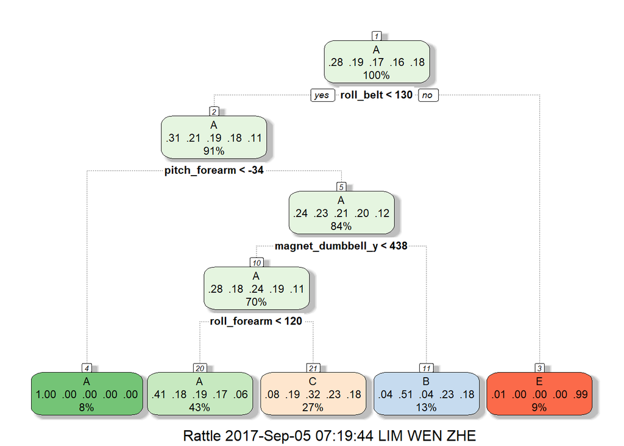

```r
fancyRpartPlot(dtFit$finalModel)
```

```r
dtFit
```

```
## CART
##
## 13737 samples
##    53 predictor
##     5 classes: 'A', 'B', 'C', 'D', 'E'
##
## No pre-processing
## Resampling: Bootstrapped (25 reps)
## Summary of sample sizes: 13737, 13737, 13737, 13737, 13737, 13737, ...
## Resampling results across tuning parameters:
##
##   cp          Accuracy   Kappa
##   0.03946699  0.5228936  0.38213555
##   0.05916658  0.4236009  0.22069736
##   0.11707863  0.3152541  0.04576361
##
## Accuracy was used to select the optimal model using  the largest value.
## The final value used for the model was cp = 0.03946699.
```

Next, we fit a random forest.The optimal number of tries is 27, yielding a significantly higher accuracy of 99.5%

```r
rfFit <- train(classe ~ ., method = "rf", data = training)
rfFit
```

```
## Random Forest
##
## 13737 samples
##    53 predictor
##     5 classes: 'A', 'B', 'C', 'D', 'E'
##
## No pre-processing
## Resampling: Bootstrapped (25 reps)
## Summary of sample sizes: 13737, 13737, 13737, 13737, 13737, 13737, ...
## Resampling results across tuning parameters:
##
##   mtry  Accuracy   Kappa
##    2    0.9912819  0.9889697
##   27    0.9956335  0.9944759
##   53    0.9922623  0.9902103
##
## Accuracy was used to select the optimal model using  the largest value.
## The final value used for the model was mtry = 27.
```

### Testing the models

```r
dtTest <- predict(dtFit, newdata = validation)
dtConfusion <- confusionMatrix(dtTest, validation$classe)
dtConfusion
```

```
## Confusion Matrix and Statistics
##
##           Reference
## Prediction    A    B    C    D    E
##          A 1522  466  466  422  158
##          B   23  383   28  170  160
##          C  124  290  532  372  293
##          D    0    0    0    0    0
##          E    5    0    0    0  471
##
## Overall Statistics
##
##                Accuracy : 0.4941
##                  95% CI : (0.4813, 0.507)
##     No Information Rate : 0.2845
##     P-Value [Acc > NIR] : < 2.2e-16
##
##                   Kappa : 0.3393
##  Mcnemar's Test P-Value : NA
##
## Statistics by Class:
##
##                      Class: A Class: B Class: C Class: D Class: E
## Sensitivity            0.9092  0.33626   0.5185   0.0000  0.43530
## Specificity            0.6409  0.91972   0.7779   1.0000  0.99896
## Pos Pred Value         0.5016  0.50131   0.3302      NaN  0.98950
## Neg Pred Value         0.9467  0.85237   0.8844   0.8362  0.88704
## Prevalence             0.2845  0.19354   0.1743   0.1638  0.18386
## Detection Rate         0.2586  0.06508   0.0904   0.0000  0.08003
## Detection Prevalence   0.5155  0.12982   0.2737   0.0000  0.08088
## Balanced Accuracy      0.7751  0.62799   0.6482   0.5000  0.71713
```

```r
rfTest <- predict(rfFit, newdata = validation)
rfConfusion <- confusionMatrix(rfTest, validation$classe)
rfConfusion
```

```
## Confusion Matrix and Statistics
##
##           Reference
## Prediction    A    B    C    D    E
##          A 1673    7    0    0    0
##          B    1 1131    1    0    0
##          C    0    1 1025    2    0
##          D    0    0    0  962    3
##          E    0    0    0    0 1079
##
## Overall Statistics
##
##                Accuracy : 0.9975
##                  95% CI : (0.9958, 0.9986)
##     No Information Rate : 0.2845
##     P-Value [Acc > NIR] : < 2.2e-16
##
##                   Kappa : 0.9968
##  Mcnemar's Test P-Value : NA
##
## Statistics by Class:
##
##                      Class: A Class: B Class: C Class: D Class: E
## Sensitivity            0.9994   0.9930   0.9990   0.9979   0.9972
## Specificity            0.9983   0.9996   0.9994   0.9994   1.0000
## Pos Pred Value         0.9958   0.9982   0.9971   0.9969   1.0000
## Neg Pred Value         0.9998   0.9983   0.9998   0.9996   0.9994
## Prevalence             0.2845   0.1935   0.1743   0.1638   0.1839
## Detection Rate         0.2843   0.1922   0.1742   0.1635   0.1833
## Detection Prevalence   0.2855   0.1925   0.1747   0.1640   0.1833
## Balanced Accuracy      0.9989   0.9963   0.9992   0.9987   0.9986
```

## Conclusion and Test Predictions

The random forest model has a higher out of sample accuracy than the decision tree, and its accuracy is comparable to that in the training set - indicating that over-fitting is not a serious problem.

The random forest model is thus used to predict the 20 cases in the test set:

```r
rfPredict <- predict(rfFit, newdata = testing)
rfPredict
```

```
##  [1] B A B A A E D B A A B C B A E E A B B B
## Levels: A B C D E
```